# Final_project

Makayla Hoggard

2025-12-08

# Final Project

For my final project I decided it would be handy for me to have a document that had all the necessary code I have done over the semester so that I can have it for future reference. So, starting out with… drum roll please…. **exploratory_data_analysis!**

```r
suppressPackageStartupMessages(source("setup.R"))
```

## **Module 1: Exploratory Data Analysis**

7. Create a figure that allows you to visualize some comparison of your choice among the `penguins` data set. Below your figure write a testable hypothesis about the data and the patterns you see from this figure.

now lets load in the data and play with it and clean it up!

```r
data("penguins")

penguins_mod <- mutate(penguins, animal = "penguins",
                       bill_length_cm = bill_length_mm/10,
                       bill_depth_cm = bill_depth_mm/10,
                       flipper_length_cm = flipper_length_mm/10)
penguins_mod <- select(penguins_mod, -c(bill_length_mm, bill_depth_mm, flipper_length_mm))
adelie <- filter(penguins_mod, species  == "Adelie")

#piping instead
adelie <- penguins %>%
  mutate(bill_length_cm = bill_length_mm/10,
         bill_depth_cm = bill_depth_mm/10,
         flipper_length_cm = flipper_length_mm/10) %>%
  select(-c(bill_length_mm, bill_depth_mm, flipper_length_mm)) %>%
  filter(species == "Adelie")
```

we want to see who has the largest flipper length lets first summarise with group_by() and summarise() grouped all data by average using species:

```r
avg_bill <- penguins %>%
  group_by(species , sex) %>%
  summarise(mean_bill_length = mean(bill_length_mm, na.rm = TRUE) , mean_flipper_length = mean(flipper_length_mm, na.rm = TRUE))
```

```r
penguins[1:5, c("species", "island")]
```

```
## # A tibble: 5 × 2
##   species island
##   <fct>   <fct>
## 1 Adelie  Torgersen
## 2 Adelie  Torgersen
## 3 Adelie  Torgersen
## 4 Adelie  Torgersen
## 5 Adelie  Torgersen
```

```r
 penguins$flipper_length_mm
```

```
##   [1] 181 186 195  NA 193 190 181 195 193 190 186 180 182 191 198 185 195 197
##  [19] 184 194 174 180 189 185 180 187 183 187 172 180 178 178 188 184 195 196
##  [37] 190 180 181 184 182 195 186 196 185 190 182 179 190 191 186 188 190 200
##  [55] 187 191 186 193 181 194 185 195 185 192 184 192 195 188 190 198 190 190
##  [73] 196 197 190 195 191 184 187 195 189 196 187 193 191 194 190 189 189 190
##  [91] 202 205 185 186 187 208 190 196 178 192 192 203 183 190 193 184 199 190
## [109] 181 197 198 191 193 197 191 196 188 199 189 189 187 198 176 202 186 199
## [127] 191 195 191 210 190 197 193 199 187 190 191 200 185 193 193 187 188 190
## [145] 192 185 190 184 195 193 187 201 211 230 210 218 215 210 211 219 209 215
## [163] 214 216 214 213 210 217 210 221 209 222 218 215 213 215 215 215 216 215
## [181] 210 220 222 209 207 230 220 220 213 219 208 208 208 225 210 216 222 217
## [199] 210 225 213 215 210 220 210 225 217 220 208 220 208 224 208 221 214 231
## [217] 219 230 214 229 220 223 216 221 221 217 216 230 209 220 215 223 212 221
## [235] 212 224 212 228 218 218 212 230 218 228 212 224 214 226 216 222 203 225
## [253] 219 228 215 228 216 215 210 219 208 209 216 229 213 230 217 230 217 222
## [271] 214  NA 215 222 212 213 192 196 193 188 197 198 178 197 195 198 193 194
## [289] 185 201 190 201 197 181 190 195 181 191 187 193 195 197 200 200 191 205
## [307] 187 201 187 203 195 199 195 210 192 205 210 187 196 196 196 201 190 212
## [325] 187 198 199 201 193 203 187 197 191 203 202 194 206 189 195 207 202 193
## [343] 210 198
```

```r
 penguins[penguins$island=='Dream',]
```

```
## # A tibble: 124 × 8
##    species island bill_length_mm bill_depth_mm flipper_length_mm body_mass_g
##    <fct>   <fct>           <dbl>         <dbl>             <int>       <int>
##  1 Adelie  Dream            39.5          16.7               178        3250
##  2 Adelie  Dream            37.2          18.1               178        3900
##  3 Adelie  Dream            39.5          17.8               188        3300
##  4 Adelie  Dream            40.9          18.9               184        3900
##  5 Adelie  Dream            36.4          17                 195        3325
##  6 Adelie  Dream            39.2          21.1               196        4150
##  7 Adelie  Dream            38.8          20                 190        3950
##  8 Adelie  Dream            42.2          18.5               180        3550
##  9 Adelie  Dream            37.6          19.3               181        3300
## 10 Adelie  Dream            39.8          19.1               184        4650
## # ℹ 114 more rows
## # ℹ 2 more variables: sex <fct>, year <int>
```

what has the largest flipper length?

```r
penguins%>%
  group_by(species) %>%
  summarise(mean_flipper_length = mean(flipper_length_mm, na.rm= TRUE))
```

```
## # A tibble: 3 × 2
##   species   mean_flipper_length
##   <fct>                   <dbl>
## 1 Adelie                   190.
## 2 Chinstrap                196.
## 3 Gentoo                   217.
```

```r
species_penguins <- penguins %>%
  distinct(species, island)
reordered_penguins <- penguins %>%
  select(year, everything())
penguins %>%
  mutate(size_group = if_else( condition = body_mass_g > 4202,
                        true = "large",
                        false = "small"))
```

```
## # A tibble: 344 × 9
##    species island    bill_length_mm bill_depth_mm flipper_length_mm body_mass_g
##    <fct>   <fct>              <dbl>         <dbl>             <int>       <int>
##  1 Adelie  Torgersen           39.1          18.7               181        3750
##  2 Adelie  Torgersen           39.5          17.4               186        3800
##  3 Adelie  Torgersen           40.3          18                 195        3250
##  4 Adelie  Torgersen           NA            NA                  NA          NA
##  5 Adelie  Torgersen           36.7          19.3               193        3450
##  6 Adelie  Torgersen           39.3          20.6               190        3650
##  7 Adelie  Torgersen           38.9          17.8               181        3625
##  8 Adelie  Torgersen           39.2          19.6               195        4675
##  9 Adelie  Torgersen           34.1          18.1               193        3475
## 10 Adelie  Torgersen           42            20.2               190        4250
## # ℹ 334 more rows
## # ℹ 3 more variables: sex <fct>, year <int>, size_group <chr>
```

lets see visually who has the highest bodymass

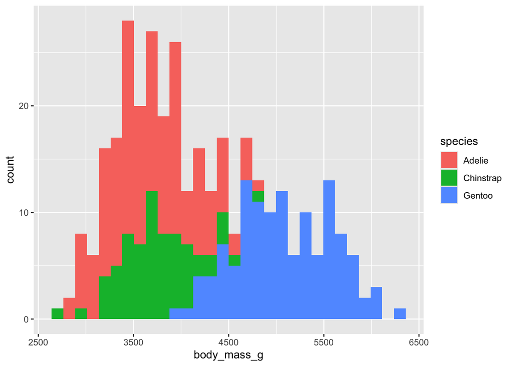

```r
ggplot(penguins) +
  geom_histogram(aes(x= body_mass_g, fill= species))
```

Yayy!!! We played with a large dataset and looked at some visuals and statistics… now whats next?

## Module 2: Plotting!!!

Now something fun we can do is make a really pretty plot and a really UGLY plot. Here are mine!

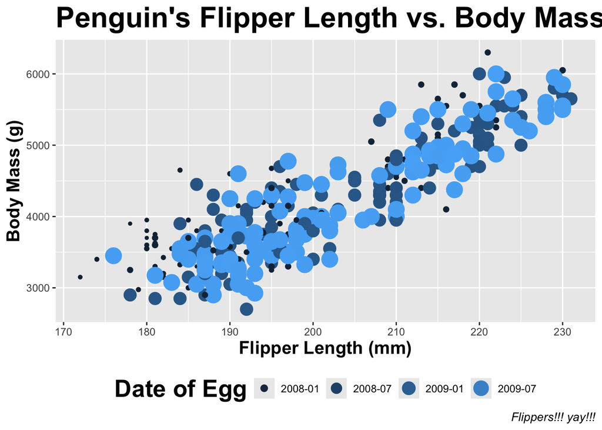

```r
penguins_raw %>%
  ggplot(aes(x=`Flipper Length (mm)`, y= `Body Mass (g)`))+
  geom_point(aes(size = `Date Egg`, color = `Date Egg`)) +
  labs(title = "Penguin's Flipper Length vs. Body Mass" ,
       x = "Flipper Length (mm)" ,
       y = "Body Mass (g)",
       caption = "Flippers!!! yay!!!") +
  guides(color = guide_legend(title = "Date of Egg"), size = guide_legend( title = "Date of Egg") )+
  theme(
    axis.title = element_text( face = "bold", size = 15),
    legend.position = "bottom",
    title = element_text(face = "bold", size = 20),
    plot.caption = element_text(face = "italic", size = 10 )
  )
```

```r
attack_data <- read.csv("data/attacks.csv")
```

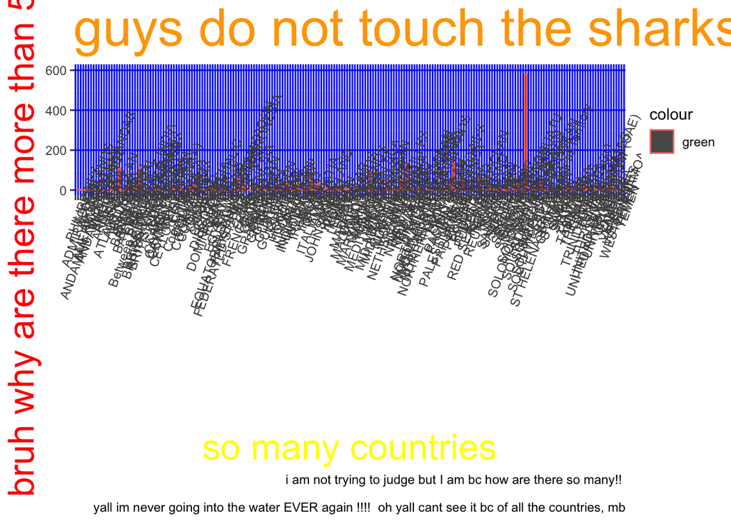

```r
attack_data %>%
ggplot(mapping = aes(x = Country)) +
  geom_bar(mapping = aes(size = 3, color = "green")) +
  ylim(c(0,600))+
  ggtitle("guys do not touch the sharks") +
  labs(
    x= "so many countries",
    y = "bruh why are there more than 500 attacks bffr",
    caption = "i am not trying to judge but I am bc how are there so many!!

    yall im never going into the water EVER again !!!!  oh yall cant see it bc of all the countries, mb"
  )+
  theme(
    plot.title = element_text(size = 36 , color = "Orange"),
    axis.title.x = element_text(size = 25 , color = "yellow"),
    axis.title.y = element_text(size = 25, color = "red"),
    panel.grid.major = element_line(color = "blue"),
    axis.text.x = element_text(angle = 70))
```

I think these plots are pretty good… next up more statstical analysis

## Module 3) T-Test and ANOVA

A t-test is used to find equal variance in a data set we can use a statistical analysis to see this.

Conduct a t-test similar to the one we carried out earlier in this lesson plan, but test for a difference in snout-vent length (`length_1_mm`) between forest types (`section`) for the *Coastal giant salamander*.

first lets clean up a data set

```r
suppressPackageStartupMessages(library(lterdatasampler))
data("and_vertebrates")
salamander <- and_vertebrates %>%
  filter(species == "Coastal giant salamander") %>%
  drop_na(length_1_mm)
```

plot it to find variation!

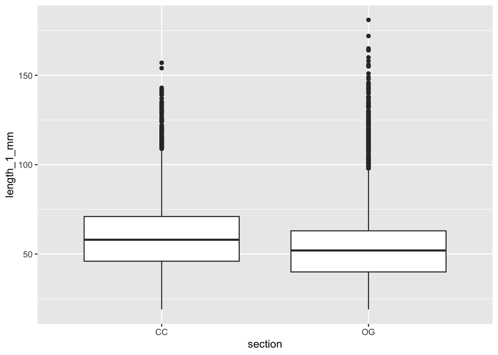

```r
salamander %>%
  ggplot(aes(x = section, y = length_1_mm)) +
  geom_boxplot()
```

the plot shows some variance but lets test it anyways

```r
library(rstatix)
salamander %>%
  levene_test(length_1_mm ~ section)
```

```
## # A tibble: 1 × 4
##     df1   df2 statistic        p
##   <int> <int>     <dbl>    <dbl>
## 1     1 11747      14.3 0.000157
```

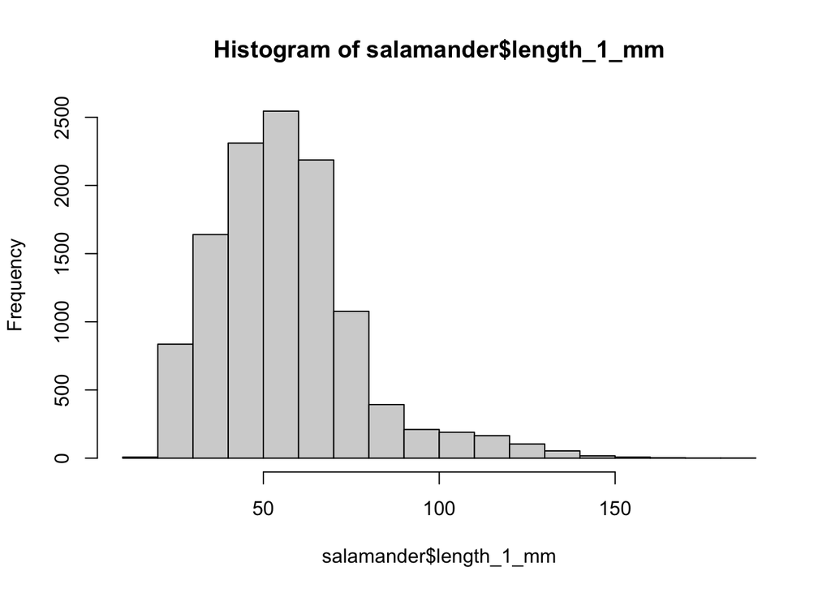

```r
hist(salamander$length_1_mm)
```

so there is def variation

has a bell curve but we know there is not equal variance lets see if we can meet assumptions using sqrt

```r
salamander %>%
   levene_test(sqrt(length_1_mm) ~ section)
```

```
## # A tibble: 1 × 4
##     df1   df2 statistic     p
##   <int> <int>     <dbl> <dbl>
## 1     1 11747     0.580 0.446
```

Bingo!!

```r
salamander %>%
  mutate(length_1_mm_sqrt = sqrt(length_1_mm)) %>%
  t_test(length_1_mm_sqrt ~ section, var.equal = TRUE, detailed = TRUE)
```

```
## # A tibble: 1 × 15
##   estimate estimate1 estimate2 .y.           group1 group2    n1    n2 statistic
## *    <dbl>     <dbl>     <dbl> <chr>         <chr>  <chr>  <int> <int>     <dbl>
## 1    0.437      7.67      7.23 length_1_mm_… CC     OG      5397  6352      18.0
## # ℹ 6 more variables: p <dbl>, df <dbl>, conf.low <dbl>, conf.high <dbl>,
## #   method <chr>, alternative <chr>
```

with this can assume that the Coastal giant salamander is observed more in old growth forests rather than in clear cut forests.

Now on to ANOVA tests!

Conduct an ANOVA test to test for differences in snout-vent length between channel types (`unittype`, only using C, P, and SC channel types) for the *Coastal Giant salamander*. Remember to check your test assumptions and use the appropriate test based on your findings. You must also conduct the associated post-hoc test and report which groups are significantly different from each other, if any.

```r
salamander_cc <- salamander %>%
  filter(section == "CC")

salamander_cc %>%
  group_by(unittype) %>%
  count()
```

```
## # A tibble: 4 × 2
## # Groups:   unittype [4]
##   unittype     n
##   <chr>    <int>
## 1 C         3748
## 2 P          711
## 3 S            2
## 4 SC         936
```

```r
salamander_cc <- salamander_cc %>%
  drop_na(unittype) %>%
  filter(unittype %in% c("C", "P", "SC"))
salamander_cc %>%
  group_by(unittype) %>%
  shapiro_test(length_1_mm)
```

```
## # A tibble: 3 × 4
##   unittype variable    statistic        p
##   <chr>    <chr>           <dbl>    <dbl>
## 1 C        length_1_mm     0.957 5.52e-32
## 2 P        length_1_mm     0.950 1.01e-14
## 3 SC       length_1_mm     0.935 1.03e-19
```

we can say that there is not even distrubution

```r
salamander_cc %>%
  kruskal_test(length_1_mm ~ unittype)
```

```
## # A tibble: 1 × 6
##   .y.             n statistic    df        p method
## * <chr>       <int>     <dbl> <int>    <dbl> <chr>
## 1 length_1_mm  5395      120.     2 7.24e-27 Kruskal-Wallis
```

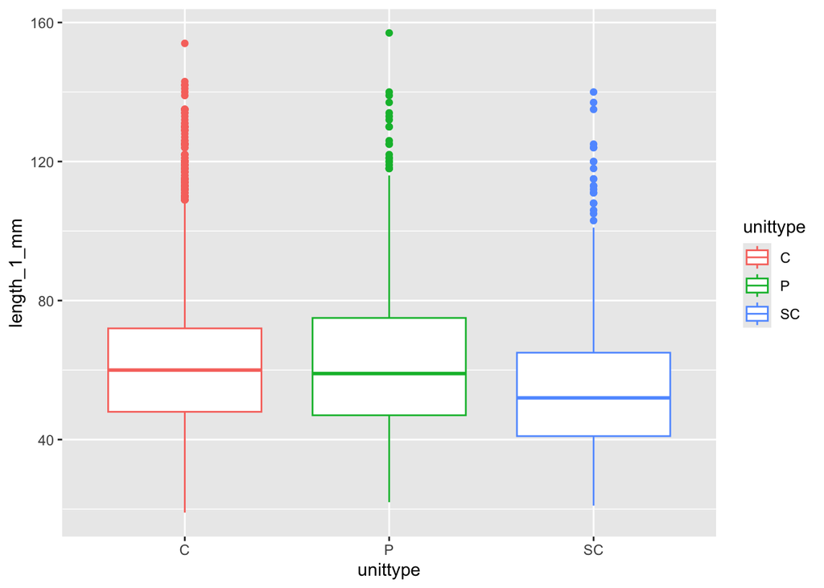

```r
salamander_cc %>%
  ggplot(aes(x = unittype, y = length_1_mm, color = unittype)) +
  geom_boxplot()
```

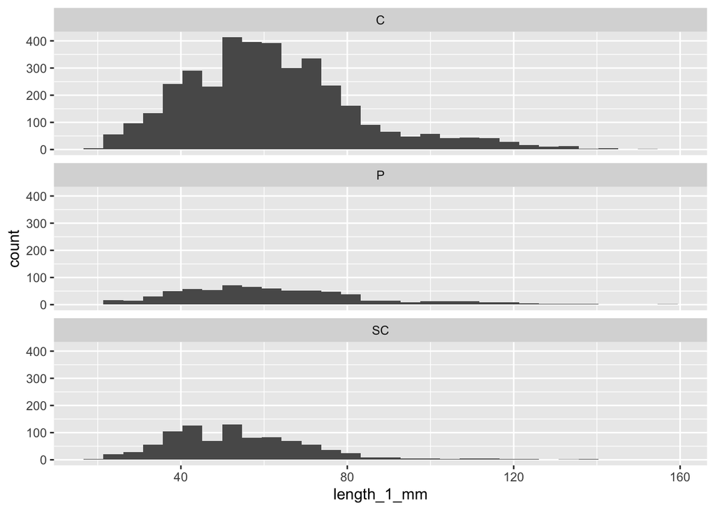

```r
salamander_cc %>%
  ggplot(aes(x = length_1_mm)) +
  geom_histogram()+
  facet_wrap(~unittype, ncol = 1)
```

```r
salamander_cc %>%
  dunn_test(length_1_mm ~ unittype)
```

```
## # A tibble: 3 × 9
##   .y.         group1 group2    n1    n2 statistic        p    p.adj p.adj.signif
## * <chr>       <chr>  <chr>  <int> <int>     <dbl>    <dbl>    <dbl> <chr>
## 1 length_1_mm C      P       3748   711     0.224 8.23e- 1 8.23e- 1 ns
## 2 length_1_mm C      SC      3748   936   -10.8   5.71e-27 1.71e-26 ****
## 3 length_1_mm P      SC       711   936    -8.08  6.35e-16 1.27e-15 ****
```

I would say after looking at the histogram and the dunn test, the length of the snout in costal giant salamander is not evenly distributed through the different channel types. I would reject ANOVA’s nul hypothesis.